# MLProjectLinearCovidData_mod

GOAL: using the patient's medical history and demographic, train a model to classify patients into different severity levels or inconclusive based on their features

target variable: classification_final

1 means TRUE

2 means FALSE

```python
import warnings
warnings.filterwarnings("ignore")
import numpy as np
import pandas as pd
import matplotlib.pyplot as plt
import seaborn as sns
import statsmodels.api as sm
```

```python
from sklearn.model_selection import train_test_split
from sklearn.linear_model import LinearRegression
from sklearn.metrics import mean_absolute_error, mean_squared_error,r2_score
from sklearn.preprocessing import LabelEncoder

pd.set_option('display.max_columns',None)
pd.set_option('display.max_rows',None)
```

```python
from google.colab import drive
drive.mount('/content/drive')
```

```python
#data1 = pd.read_csv('/content/drive/MyDrive/Covid Data (2).csv')
data = pd.read_csv('/content/drive/MyDrive/Covid Data 2.csv')
```

```python
df= data.copy()
```

```python
df.head()
```

|  | USMER | MEDICAL_UNIT | SEX | PATIENT_TYPE | DATE_DIED | INTUBED | PNEUMONIA | AGE | PREGNANT | DIABETES | COPD | ASTHMA | INMSUPR | HIPERTENSION | OTHER_DISEASE | CARDIOVASCULAR | OBESITY | RENAL_CHRONIC | TOBACCO | CLASIFFICATION_FINAL | ICU |
| --- | --- | --- | --- | --- | --- | --- | --- | --- | --- | --- | --- | --- | --- | --- | --- | --- | --- | --- | --- | --- | --- |
| 0 | 2 | 1 | 1 | 1 | 3/5/20 | NaN | 1.0 | 65 | 2.0 | 2.0 | 2.0 | 2.0 | 2.0 | 1.0 | 2.0 | 2.0 | 2.0 | 2.0 | 2.0 | 3 | NaN |
| 1 | 2 | 1 | 2 | 1 | 3/6/20 | NaN | 1.0 | 72 | NaN | 2.0 | 2.0 | 2.0 | 2.0 | 1.0 | 2.0 | 2.0 | 1.0 | 1.0 | 2.0 | 5 | NaN |
| 2 | 2 | 1 | 2 | 2 | 9/6/20 | 1.0 | 2.0 | 55 | NaN | 1.0 | 2.0 | 2.0 | 2.0 | 2.0 | 2.0 | 2.0 | 2.0 | 2.0 | 2.0 | 3 | 2.0 |
| 3 | 2 | 1 | 1 | 1 | 12/6/20 | NaN | 2.0 | 53 | 2.0 | 2.0 | 2.0 | 2.0 | 2.0 | 2.0 | 2.0 | 2.0 | 2.0 | 2.0 | 2.0 | 7 | NaN |
| 4 | 2 | 1 | 2 | 1 | 21/06/2020 | NaN | 2.0 | 68 | NaN | 1.0 | 2.0 | 2.0 | 2.0 | 1.0 | 2.0 | 2.0 | 2.0 | 2.0 | 2.0 | 3 | NaN |

```python
df.shape
```

```
(1048575, 21)
```

```python
df.info()
```

```
<class 'pandas.core.frame.DataFrame'>
RangeIndex: 1048575 entries, 0 to 1048574
Data columns (total 21 columns):
 #   Column                Non-Null Count    Dtype
---  ------                --------------    -----
 0   USMER                 1048575 non-null  int64
 1   MEDICAL_UNIT          1048575 non-null  int64
 2   SEX                   1048575 non-null  int64
 3   PATIENT_TYPE          1048575 non-null  int64
 4   DATE_DIED             76942 non-null    object
 5   INTUBED               192706 non-null   float64
 6   PNEUMONIA             1032572 non-null  float64
 7   AGE                   1048575 non-null  int64
 8   PREGNANT              521310 non-null   float64
 9   DIABETES              1045237 non-null  float64
 10  COPD                  1045572 non-null  float64
 11  ASTHMA                1045596 non-null  float64
 12  INMSUPR               1045171 non-null  float64
 13  HIPERTENSION          1045471 non-null  float64
 14  OTHER_DISEASE         1043530 non-null  float64
 15  CARDIOVASCULAR        1045499 non-null  float64
 16  OBESITY               1045543 non-null  float64
 17  RENAL_CHRONIC         1045569 non-null  float64
 18  TOBACCO               1045355 non-null  float64
 19  CLASIFFICATION_FINAL  1048575 non-null  int64
 20  ICU                   192543 non-null   float64
dtypes: float64(14), int64(6), object(1)
memory usage: 168.0+ MB
```

```python
df.columns
```

```
Index(['USMER', 'MEDICAL_UNIT', 'SEX', 'PATIENT_TYPE', 'DATE_DIED', 'INTUBED',
       'PNEUMONIA', 'AGE', 'PREGNANT', 'DIABETES', 'COPD', 'ASTHMA', 'INMSUPR',
       'HIPERTENSION', 'OTHER_DISEASE', 'CARDIOVASCULAR', 'OBESITY',
       'RENAL_CHRONIC', 'TOBACCO', 'CLASIFFICATION_FINAL', 'ICU'],
      dtype='object')
```

Observations about the dataset:

USMER: treated medical units of the first, second, or third level

Medical_unit: type of institution of the national health system that provided care

sex: 1 for female 2 for male

patient_type:

1: returned home 2: hospitalized

date died: 9999-99-99

intubed: intubated or not

pneuomonia

age: numerical age

pregnant: pregnant or not

diabetes: has diabetes or not

copd: chronic obstructive pulmonary disease or not

asthma: is asthmatic or not

imnsupr: is immunosupressed or not

hypertension: is hypertensive or not

other disease: whether the patient has other diseases or no

cardiovascular: patient has cardiovascular disease

obesity: is obsese or not

renal: has renal disease or not

tobacco: uses tobacco or no

classification_final:

1: covid with degree 1

2: covid degree 2

3: covid degree 3

4+: not a carrier of covid, inconclusive

icu: has been admitted to icu or no

```python
df.head()
```

|  | USMER | MEDICAL_UNIT | SEX | PATIENT_TYPE | DATE_DIED | INTUBED | PNEUMONIA | AGE | PREGNANT | DIABETES | COPD | ASTHMA | INMSUPR | HIPERTENSION | OTHER_DISEASE | CARDIOVASCULAR | OBESITY | RENAL_CHRONIC | TOBACCO | CLASIFFICATION_FINAL | ICU |
| --- | --- | --- | --- | --- | --- | --- | --- | --- | --- | --- | --- | --- | --- | --- | --- | --- | --- | --- | --- | --- | --- |
| 0 | 2 | 1 | 1 | 1 | 3/5/20 | NaN | 1.0 | 65 | 2.0 | 2.0 | 2.0 | 2.0 | 2.0 | 1.0 | 2.0 | 2.0 | 2.0 | 2.0 | 2.0 | 3 | NaN |
| 1 | 2 | 1 | 2 | 1 | 3/6/20 | NaN | 1.0 | 72 | NaN | 2.0 | 2.0 | 2.0 | 2.0 | 1.0 | 2.0 | 2.0 | 1.0 | 1.0 | 2.0 | 5 | NaN |
| 2 | 2 | 1 | 2 | 2 | 9/6/20 | 1.0 | 2.0 | 55 | NaN | 1.0 | 2.0 | 2.0 | 2.0 | 2.0 | 2.0 | 2.0 | 2.0 | 2.0 | 2.0 | 3 | 2.0 |
| 3 | 2 | 1 | 1 | 1 | 12/6/20 | NaN | 2.0 | 53 | 2.0 | 2.0 | 2.0 | 2.0 | 2.0 | 2.0 | 2.0 | 2.0 | 2.0 | 2.0 | 2.0 | 7 | NaN |
| 4 | 2 | 1 | 2 | 1 | 21/06/2020 | NaN | 2.0 | 68 | NaN | 1.0 | 2.0 | 2.0 | 2.0 | 1.0 | 2.0 | 2.0 | 2.0 | 2.0 | 2.0 | 3 | NaN |

```python
df.describe(include = 'all').T
#is medical_unit useful?
```

|  | count | unique | top | freq | mean | std | min | 25% | 50% | 75% | max |
| --- | --- | --- | --- | --- | --- | --- | --- | --- | --- | --- | --- |
| USMER | 1048575.0 | NaN | NaN | NaN | 1.632194 | 0.482208 | 1.0 | 1.0 | 2.0 | 2.0 | 2.0 |
| MEDICAL_UNIT | 1048575.0 | NaN | NaN | NaN | 8.980565 | 3.723278 | 1.0 | 4.0 | 12.0 | 12.0 | 13.0 |
| SEX | 1048575.0 | NaN | NaN | NaN | 1.499259 | 0.5 | 1.0 | 1.0 | 1.0 | 2.0 | 2.0 |
| PATIENT_TYPE | 1048575.0 | NaN | NaN | NaN | 1.190765 | 0.392904 | 1.0 | 1.0 | 1.0 | 1.0 | 2.0 |
| DATE_DIED | 76942 | 400 | 6/7/20 | 1000 | NaN | NaN | NaN | NaN | NaN | NaN | NaN |
| INTUBED | 192706.0 | NaN | NaN | NaN | 1.825351 | 0.379668 | 1.0 | 2.0 | 2.0 | 2.0 | 2.0 |
| PNEUMONIA | 1032572.0 | NaN | NaN | NaN | 1.864379 | 0.342385 | 1.0 | 2.0 | 2.0 | 2.0 | 2.0 |
| AGE | 1048575.0 | NaN | NaN | NaN | 41.794102 | 16.907389 | 0.0 | 30.0 | 40.0 | 53.0 | 121.0 |
| PREGNANT | 521310.0 | NaN | NaN | NaN | 1.984403 | 0.123911 | 1.0 | 2.0 | 2.0 | 2.0 | 2.0 |
| DIABETES | 1045237.0 | NaN | NaN | NaN | 1.88042 | 0.324469 | 1.0 | 2.0 | 2.0 | 2.0 | 2.0 |
| COPD | 1045572.0 | NaN | NaN | NaN | 1.985594 | 0.119155 | 1.0 | 2.0 | 2.0 | 2.0 | 2.0 |
| ASTHMA | 1045596.0 | NaN | NaN | NaN | 1.969805 | 0.171124 | 1.0 | 2.0 | 2.0 | 2.0 | 2.0 |
| INMSUPR | 1045171.0 | NaN | NaN | NaN | 1.986442 | 0.115645 | 1.0 | 2.0 | 2.0 | 2.0 | 2.0 |
| HIPERTENSION | 1045471.0 | NaN | NaN | NaN | 1.844349 | 0.362525 | 1.0 | 2.0 | 2.0 | 2.0 | 2.0 |
| OTHER_DISEASE | 1043530.0 | NaN | NaN | NaN | 1.97313 | 0.161704 | 1.0 | 2.0 | 2.0 | 2.0 | 2.0 |
| CARDIOVASCULAR | 1045499.0 | NaN | NaN | NaN | 1.980135 | 0.139537 | 1.0 | 2.0 | 2.0 | 2.0 | 2.0 |
| OBESITY | 1045543.0 | NaN | NaN | NaN | 1.847145 | 0.359847 | 1.0 | 2.0 | 2.0 | 2.0 | 2.0 |
| RENAL_CHRONIC | 1045569.0 | NaN | NaN | NaN | 1.98192 | 0.133241 | 1.0 | 2.0 | 2.0 | 2.0 | 2.0 |
| TOBACCO | 1045355.0 | NaN | NaN | NaN | 1.919285 | 0.272397 | 1.0 | 2.0 | 2.0 | 2.0 | 2.0 |
| CLASIFFICATION_FINAL | 1048575.0 | NaN | NaN | NaN | 5.305653 | 1.881165 | 1.0 | 3.0 | 6.0 | 7.0 | 7.0 |
| ICU | 192543.0 | NaN | NaN | NaN | 1.912446 | 0.282647 | 1.0 | 2.0 | 2.0 | 2.0 | 2.0 |

```python
df.drop(['MEDICAL_UNIT'],axis=1,inplace=True)
```

```python
df.shape
```

```
(1048575, 20)
```

```python
#check sum of null vals in each col
df.isna().sum()
```

```
USMER                        0
SEX                          0
PATIENT_TYPE                 0
DATE_DIED               971633
INTUBED                 855869
PNEUMONIA                16003
AGE                          0
PREGNANT                527265
DIABETES                  3338
COPD                      3003
ASTHMA                    2979
INMSUPR                   3404
HIPERTENSION              3104
OTHER_DISEASE             5045
CARDIOVASCULAR            3076
OBESITY                   3032
RENAL_CHRONIC             3006
TOBACCO                   3220
CLASIFFICATION_FINAL         0
ICU                     856032
dtype: int64
```

```python
#remove null vals in cols of type object
#data.dropna(axis=0,subset=['DATE_DIED','PNEUMONIA','PREGNANT','DIABETES','COPD','ASTHMA','INMSUPR','HIPERTENSION','OTHER_DISEASE','CARDIOVASCULAR','OBESITY','RENAL_CHRONIC','TOBACCO','ICU'],inplace=True)
```

```python
#filling in NULL vals
df.INTUBED.fillna(2,inplace=True)
df.PNEUMONIA.fillna(2,inplace=True)
df.PREGNANT.fillna(2,inplace=True)
df.DIABETES.fillna(2,inplace=True)
df.COPD.fillna(2,inplace=True)
df.ASTHMA.fillna(2,inplace=True)
df.INMSUPR.fillna(2,inplace=True)
df.HIPERTENSION.fillna(2,inplace=True)
df.OTHER_DISEASE.fillna(2,inplace=True)
df.CARDIOVASCULAR.fillna(2,inplace=True)
df.OBESITY.fillna(2,inplace=True)
df.RENAL_CHRONIC.fillna(2,inplace=True)
df.TOBACCO.fillna(2,inplace=True)
df.ICU.fillna(2,inplace=True)
```

```python
df['CLASIFFICATION_FINAL']= df['CLASIFFICATION_FINAL'].apply(lambda x:4 if x > 4  else x)
```

```python
#data['DATE_DIED']= pd.to_datetime(data['DATE_DIED'],errors='coerce')
```

```python
df.head()
```

|  | USMER | SEX | PATIENT_TYPE | DATE_DIED | INTUBED | PNEUMONIA | AGE | PREGNANT | DIABETES | COPD | ASTHMA | INMSUPR | HIPERTENSION | OTHER_DISEASE | CARDIOVASCULAR | OBESITY | RENAL_CHRONIC | TOBACCO | CLASIFFICATION_FINAL | ICU |
| --- | --- | --- | --- | --- | --- | --- | --- | --- | --- | --- | --- | --- | --- | --- | --- | --- | --- | --- | --- | --- |
| 0 | 2 | 1 | 1 | 3/5/20 | 2.0 | 1.0 | 65 | 2.0 | 2.0 | 2.0 | 2.0 | 2.0 | 1.0 | 2.0 | 2.0 | 2.0 | 2.0 | 2.0 | 3 | 2.0 |
| 1 | 2 | 2 | 1 | 3/6/20 | 2.0 | 1.0 | 72 | 2.0 | 2.0 | 2.0 | 2.0 | 2.0 | 1.0 | 2.0 | 2.0 | 1.0 | 1.0 | 2.0 | 4 | 2.0 |
| 2 | 2 | 2 | 2 | 9/6/20 | 1.0 | 2.0 | 55 | 2.0 | 1.0 | 2.0 | 2.0 | 2.0 | 2.0 | 2.0 | 2.0 | 2.0 | 2.0 | 2.0 | 3 | 2.0 |
| 3 | 2 | 1 | 1 | 12/6/20 | 2.0 | 2.0 | 53 | 2.0 | 2.0 | 2.0 | 2.0 | 2.0 | 2.0 | 2.0 | 2.0 | 2.0 | 2.0 | 2.0 | 4 | 2.0 |
| 4 | 2 | 2 | 1 | 21/06/2020 | 2.0 | 2.0 | 68 | 2.0 | 1.0 | 2.0 | 2.0 | 2.0 | 1.0 | 2.0 | 2.0 | 2.0 | 2.0 | 2.0 | 3 | 2.0 |

```python
df.isna().sum()
```

```
USMER                        0
SEX                          0
PATIENT_TYPE                 0
DATE_DIED               971633
INTUBED                      0
PNEUMONIA                    0
AGE                          0
PREGNANT                     0
DIABETES                     0
COPD                         0
ASTHMA                       0
INMSUPR                      0
HIPERTENSION                 0
OTHER_DISEASE                0
CARDIOVASCULAR               0
OBESITY                      0
RENAL_CHRONIC                0
TOBACCO                      0
CLASIFFICATION_FINAL         0
ICU                          0
dtype: int64
```

```python
df.shape
```

```
(1048575, 20)
```

```python
df.describe(include='all').T
```

|  | count | unique | top | freq | mean | std | min | 25% | 50% | 75% | max |
| --- | --- | --- | --- | --- | --- | --- | --- | --- | --- | --- | --- |
| USMER | 1048575.0 | NaN | NaN | NaN | 1.632194 | 0.482208 | 1.0 | 1.0 | 2.0 | 2.0 | 2.0 |
| SEX | 1048575.0 | NaN | NaN | NaN | 1.499259 | 0.5 | 1.0 | 1.0 | 1.0 | 2.0 | 2.0 |
| PATIENT_TYPE | 1048575.0 | NaN | NaN | NaN | 1.190765 | 0.392904 | 1.0 | 1.0 | 1.0 | 1.0 | 2.0 |
| DATE_DIED | 76942 | 400 | 6/7/20 | 1000 | NaN | NaN | NaN | NaN | NaN | NaN | NaN |
| INTUBED | 1048575.0 | NaN | NaN | NaN | 1.967903 | 0.176258 | 1.0 | 2.0 | 2.0 | 2.0 | 2.0 |
| PNEUMONIA | 1048575.0 | NaN | NaN | NaN | 1.866449 | 0.340169 | 1.0 | 2.0 | 2.0 | 2.0 | 2.0 |
| AGE | 1048575.0 | NaN | NaN | NaN | 41.794102 | 16.907389 | 0.0 | 30.0 | 40.0 | 53.0 | 121.0 |
| PREGNANT | 1048575.0 | NaN | NaN | NaN | 1.992246 | 0.087717 | 1.0 | 2.0 | 2.0 | 2.0 | 2.0 |
| DIABETES | 1048575.0 | NaN | NaN | NaN | 1.880801 | 0.324023 | 1.0 | 2.0 | 2.0 | 2.0 | 2.0 |
| COPD | 1048575.0 | NaN | NaN | NaN | 1.985636 | 0.118987 | 1.0 | 2.0 | 2.0 | 2.0 | 2.0 |
| ASTHMA | 1048575.0 | NaN | NaN | NaN | 1.969891 | 0.170889 | 1.0 | 2.0 | 2.0 | 2.0 | 2.0 |
| INMSUPR | 1048575.0 | NaN | NaN | NaN | 1.986486 | 0.11546 | 1.0 | 2.0 | 2.0 | 2.0 | 2.0 |
| HIPERTENSION | 1048575.0 | NaN | NaN | NaN | 1.844809 | 0.362086 | 1.0 | 2.0 | 2.0 | 2.0 | 2.0 |
| OTHER_DISEASE | 1048575.0 | NaN | NaN | NaN | 1.973259 | 0.161326 | 1.0 | 2.0 | 2.0 | 2.0 | 2.0 |
| CARDIOVASCULAR | 1048575.0 | NaN | NaN | NaN | 1.980193 | 0.139336 | 1.0 | 2.0 | 2.0 | 2.0 | 2.0 |
| OBESITY | 1048575.0 | NaN | NaN | NaN | 1.847587 | 0.35942 | 1.0 | 2.0 | 2.0 | 2.0 | 2.0 |
| RENAL_CHRONIC | 1048575.0 | NaN | NaN | NaN | 1.981972 | 0.133054 | 1.0 | 2.0 | 2.0 | 2.0 | 2.0 |
| TOBACCO | 1048575.0 | NaN | NaN | NaN | 1.919533 | 0.272015 | 1.0 | 2.0 | 2.0 | 2.0 | 2.0 |
| CLASIFFICATION_FINAL | 1048575.0 | NaN | NaN | NaN | 3.608009 | 0.539518 | 1.0 | 3.0 | 4.0 | 4.0 | 4.0 |
| ICU | 1048575.0 | NaN | NaN | NaN | 1.983923 | 0.125772 | 1.0 | 2.0 | 2.0 | 2.0 | 2.0 |

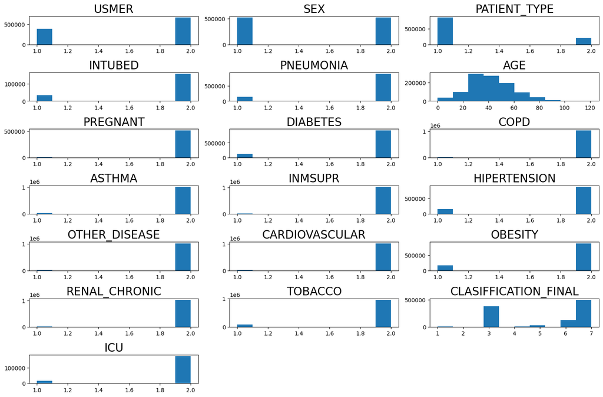

```python
#start univariate analysis
# histogram
num_cols = df.select_dtypes(include=np.number).columns.tolist()
plt.figure(figsize=(15,25))
for i in range(len(num_cols)):
  plt.subplot(18,3,i+1)
  plt.hist(data[num_cols[i]])
  plt.tight_layout()
  plt.title(num_cols[i],fontsize=20)

plt.show()
```

plot categorical variables

```python
#plot all categorical variables THERE ARE 17 ( not including date)
'''
plt.figure(figsize=(20,25))

plt.subplot(1,2,1)
sns.countplot(data['ASTHMA'])
plt.xlabel('Asthma')

plt.subplot(1,2,2)
sns.countplot(data['CARDIOVASCULAR'])
plt.xlabel('Cardiovascular disease')

plt.subplot(1,2,3)
sns.countplot(data['COPD'])
plt.xlabel('COPD')

plt.show()
'''
```

```
"\nplt.figure(figsize=(20,25))\n\nplt.subplot(1,2,1)\nsns.countplot(data['ASTHMA'])\nplt.xlabel('Asthma')\n\nplt.subplot(1,2,2)\nsns.countplot(data['CARDIOVASCULAR'])\nplt.xlabel('Cardiovascular disease')\n\nplt.subplot(1,2,3)\nsns.countplot(data['COPD'])\nplt.xlabel('COPD')\n\nplt.show()\n"
```

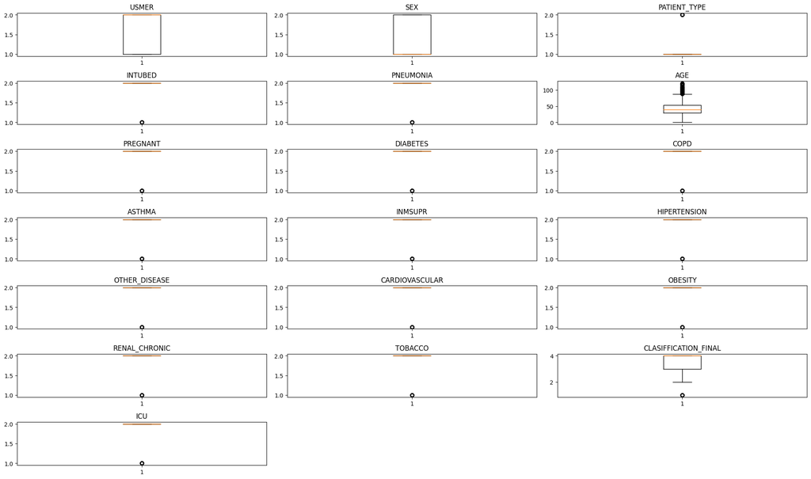

```python
#outlier detection using boxplots
plt.figure(figsize=(20,20))

for i, variable in enumerate(num_cols):
  plt.subplot(12,3,i+1)
  plt.boxplot(df[variable],vert=True)
  plt.tight_layout()
  plt.title(variable)
```

[figure not shown]

```python
#multivariate analysis

plt.figure(figsize=(45,20))
obj_col = df.select_dtypes(include =object).columns.tolist()
for i in range(len(obj_col)):
  plt.subplot(18,3,i+1)
  sns.barplot(x=obj_col[i], y= df['CLASIFFICATION_FINAL'],data=df,ci=None)
  plt.tight_layout()
  plt.title(obj_col[i],fontsize=15)
plt.show()
```

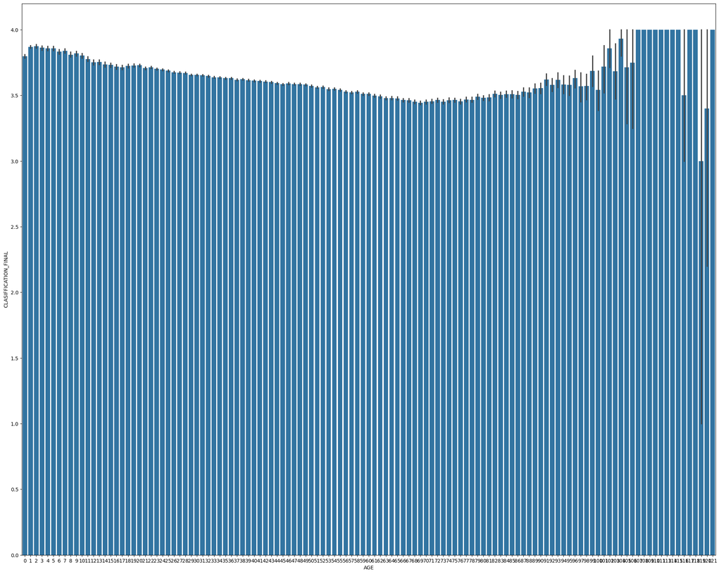

```python
plt.figure(figsize=(25,20))
sns.barplot(x='AGE',y='CLASIFFICATION_FINAL', data=df)
```

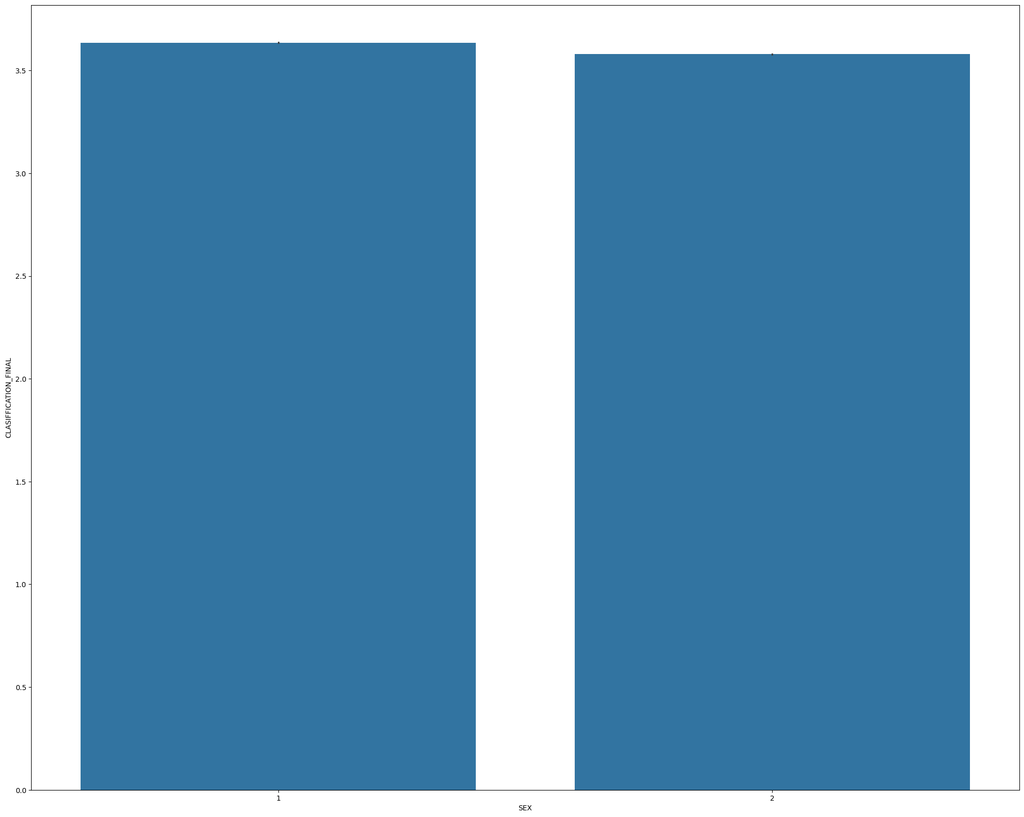

```python
plt.figure(figsize=(25,20))
sns.barplot(x='SEX',y='CLASIFFICATION_FINAL',data=df)
```

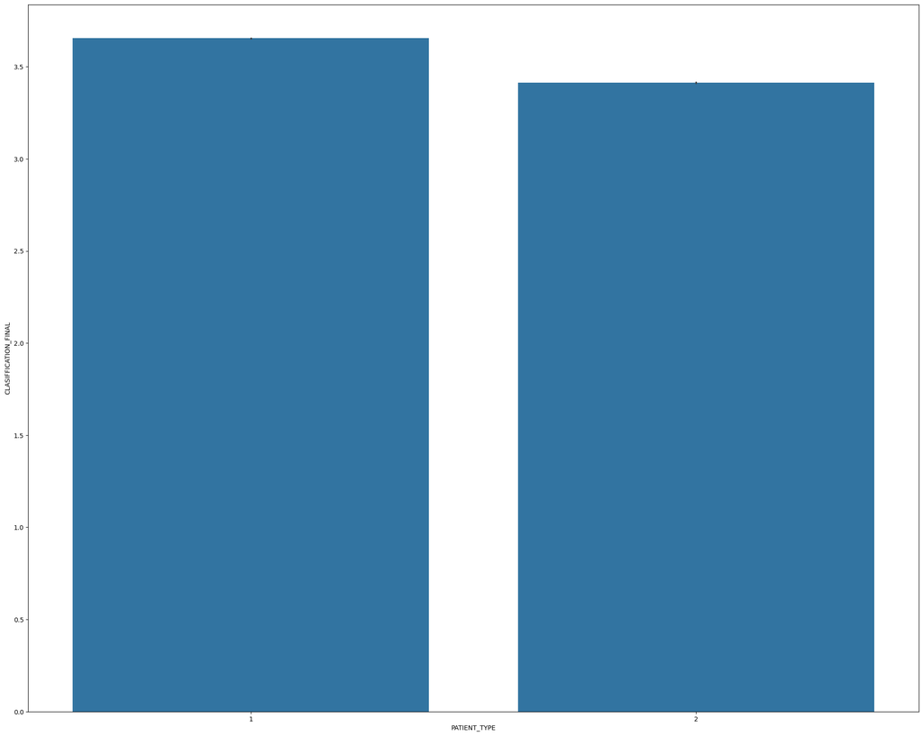

```python
plt.figure(figsize=(25,20))
sns.barplot(x='PATIENT_TYPE',y='CLASIFFICATION_FINAL',data=df)
```

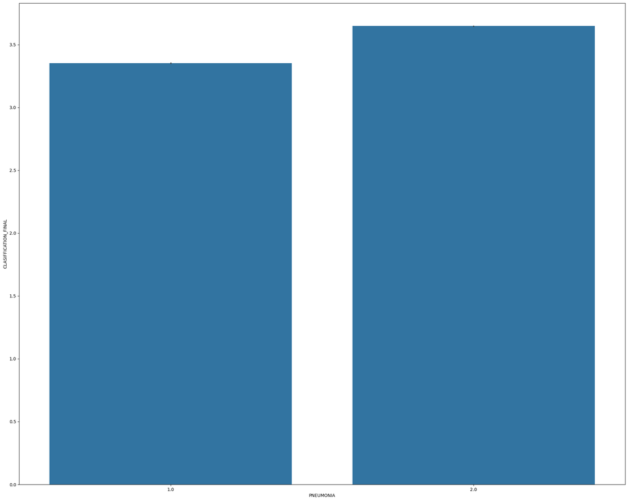

```python
plt.figure(figsize=(25,20))
sns.barplot(x='PNEUMONIA',y='CLASIFFICATION_FINAL',data=df)
```

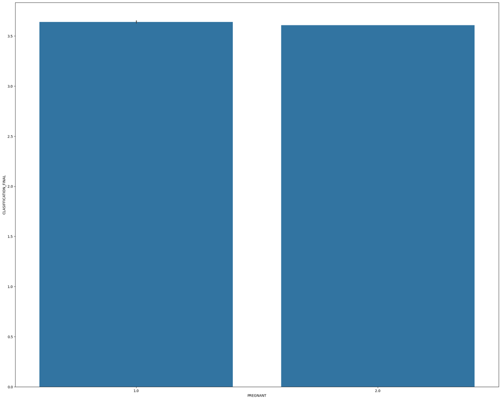

```python
plt.figure(figsize=(25,20))
sns.barplot(x='PREGNANT',y='CLASIFFICATION_FINAL',data=df)
```

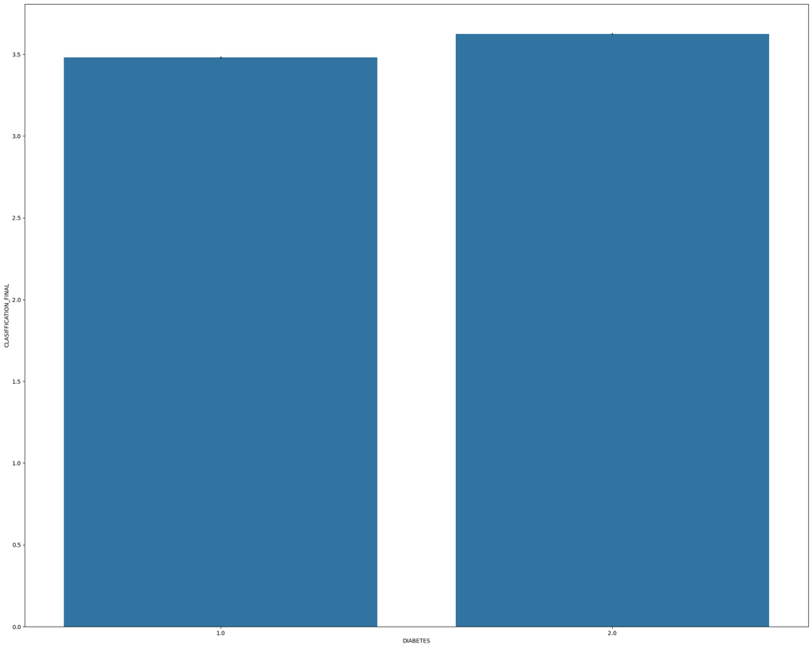

```python
plt.figure(figsize=(25,20))
sns.barplot(x='DIABETES',y='CLASIFFICATION_FINAL',data=df)
```

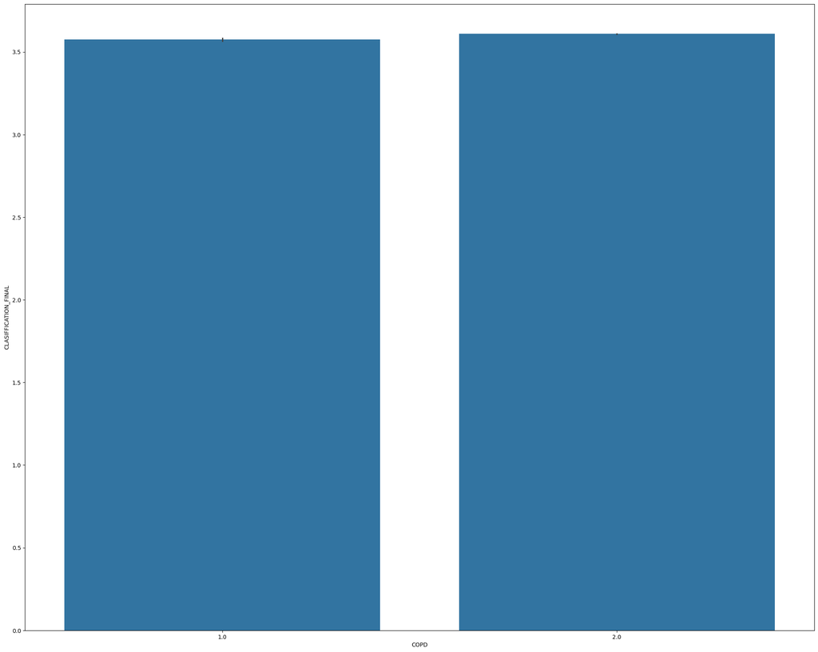

```python
plt.figure(figsize=(25,20))
sns.barplot(x='COPD',y='CLASIFFICATION_FINAL',data=df)
```

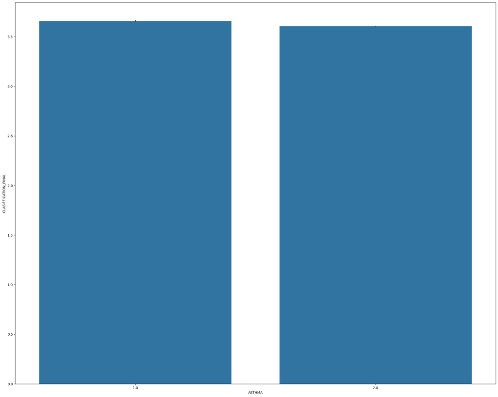

```python
plt.figure(figsize=(25,20))
sns.barplot(x='ASTHMA',y='CLASIFFICATION_FINAL',data=df)
```

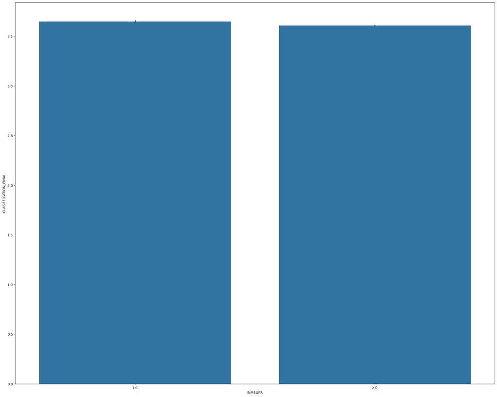

```python
plt.figure(figsize=(25,20))
sns.barplot(x='INMSUPR',y='CLASIFFICATION_FINAL',data=df)
```

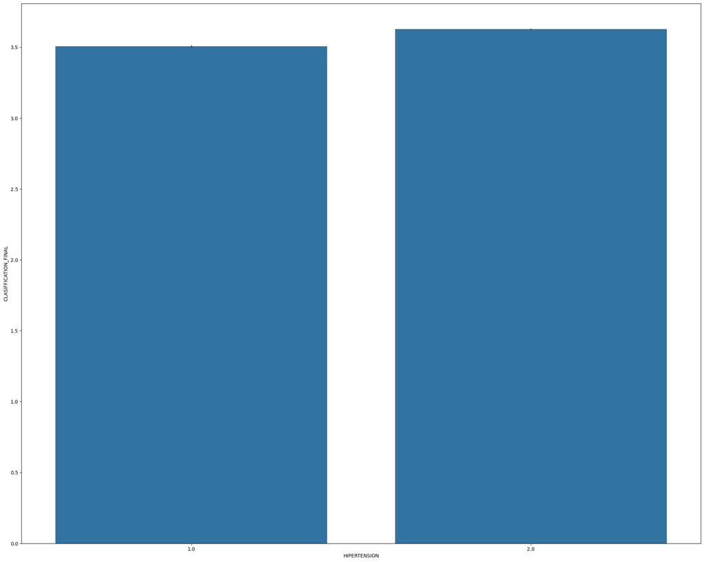

```python
plt.figure(figsize=(25,20))
sns.barplot(x='HIPERTENSION',y='CLASIFFICATION_FINAL',data=df)
```

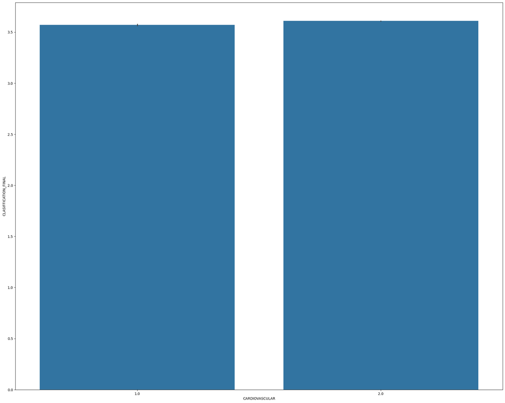

```python
plt.figure(figsize=(25,20))
sns.barplot(x='CARDIOVASCULAR',y='CLASIFFICATION_FINAL',data=df)
```

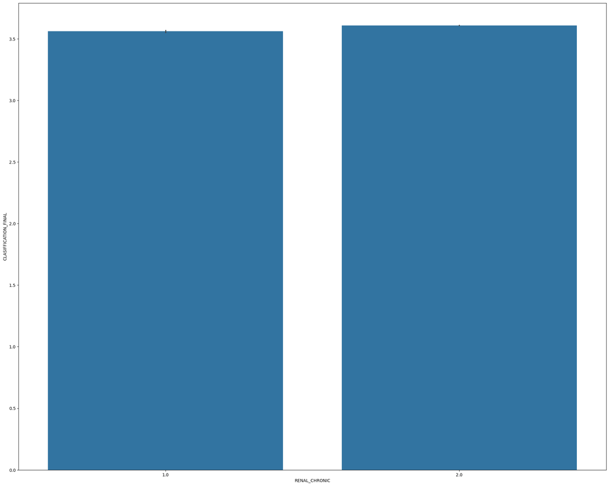

```python
plt.figure(figsize=(25,20))
sns.barplot(x='RENAL_CHRONIC',y='CLASIFFICATION_FINAL',data=df)
```

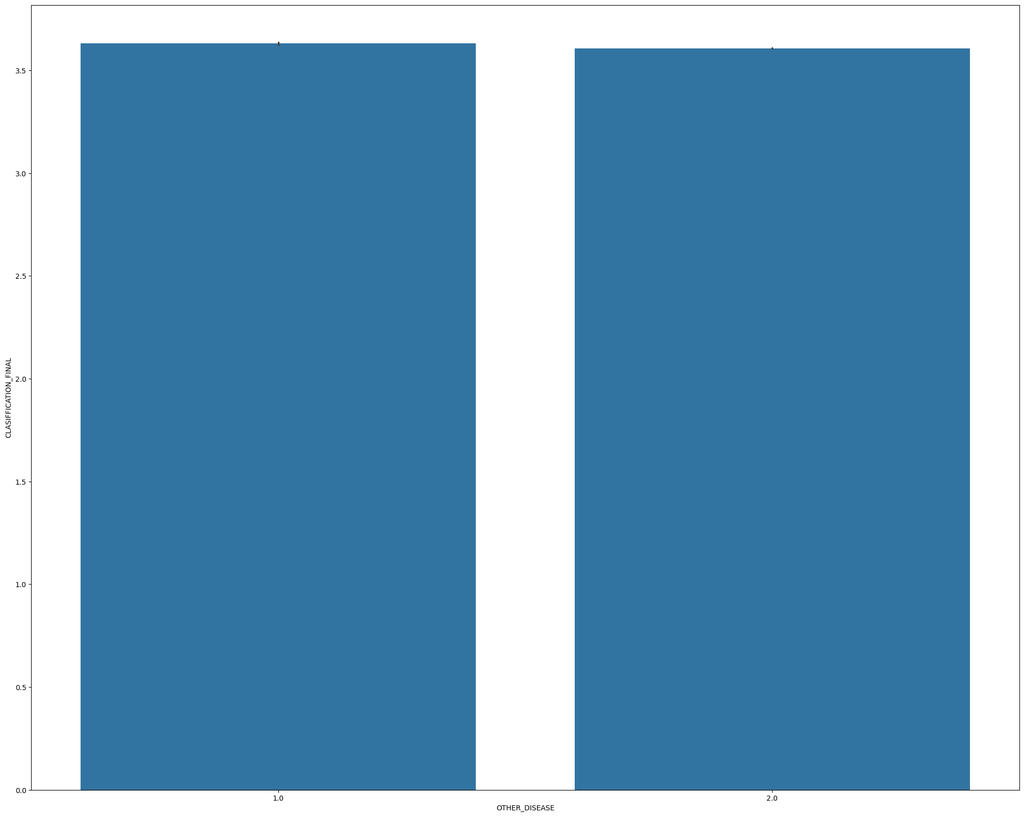

```python
plt.figure(figsize=(25,20))
sns.barplot(x='OTHER_DISEASE',y='CLASIFFICATION_FINAL',data=df)
```

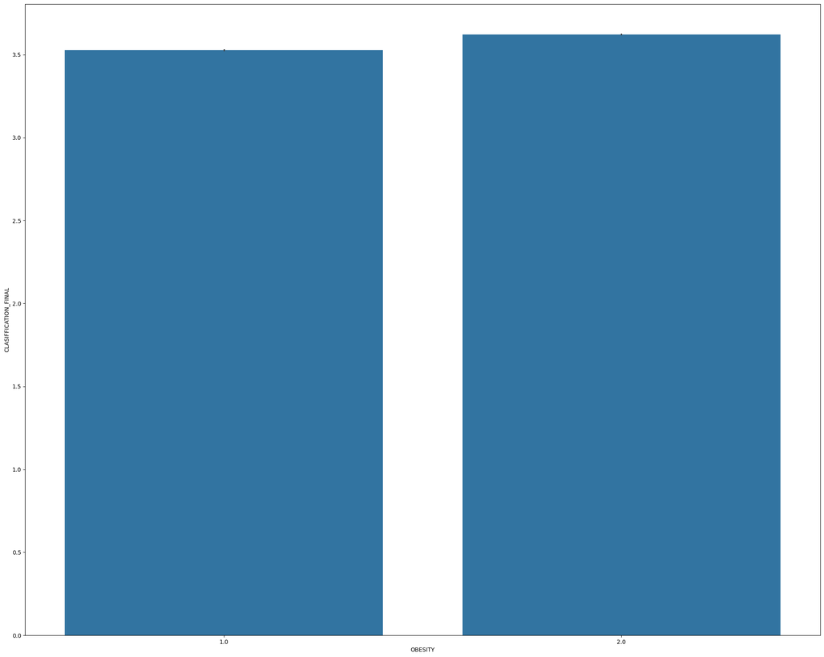

```python
plt.figure(figsize=(25,20))
sns.barplot(x='OBESITY',y='CLASIFFICATION_FINAL',data=df)
```

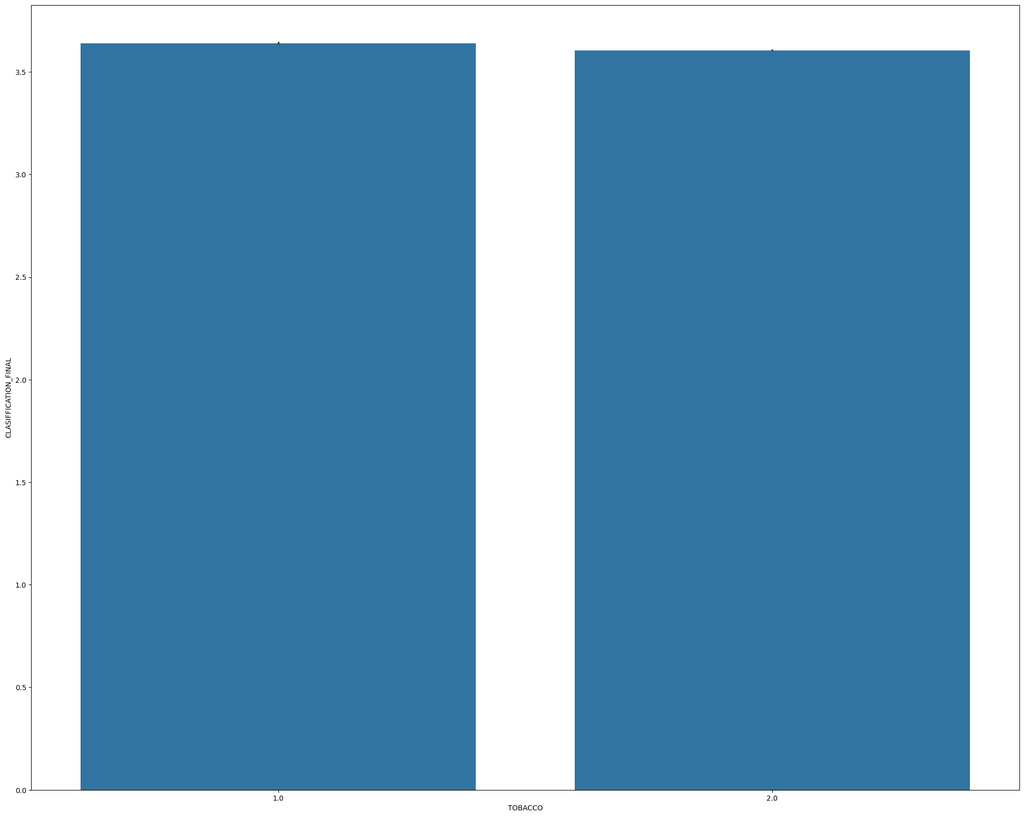

```python
plt.figure(figsize=(25,20))
sns.barplot(x='TOBACCO',y='CLASIFFICATION_FINAL',data=df)
```

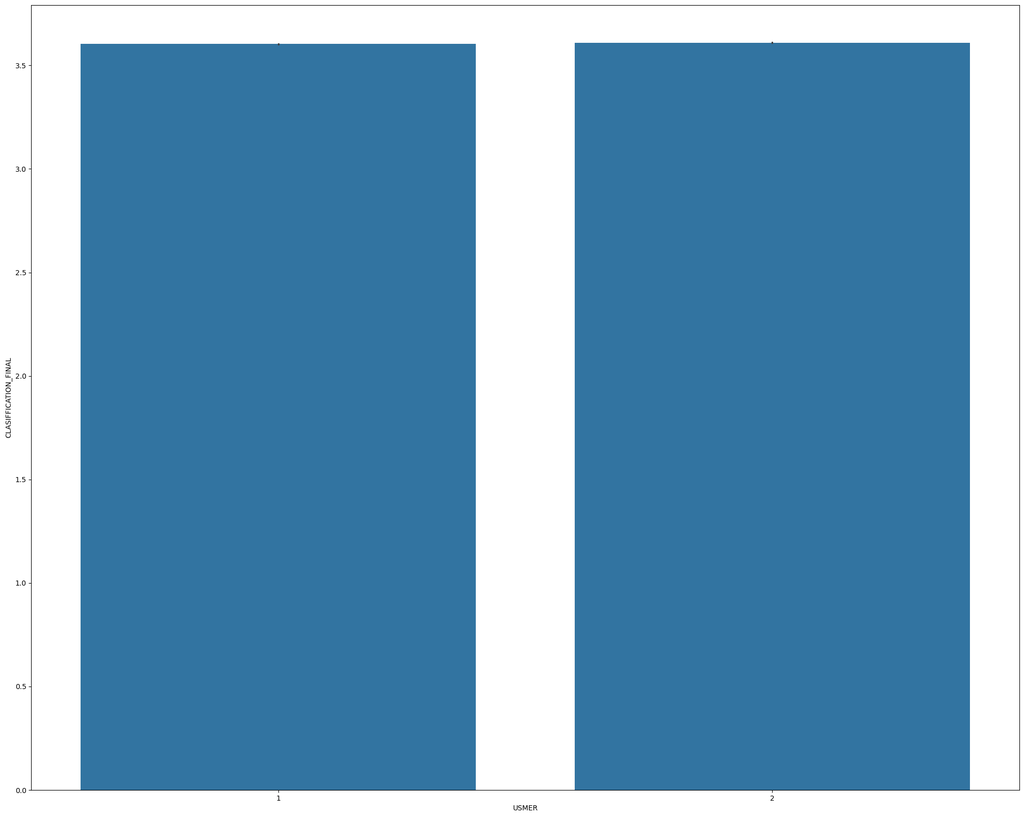

```python
plt.figure(figsize=(25,20))
sns.barplot(x='USMER',y='CLASIFFICATION_FINAL',data=df)
```

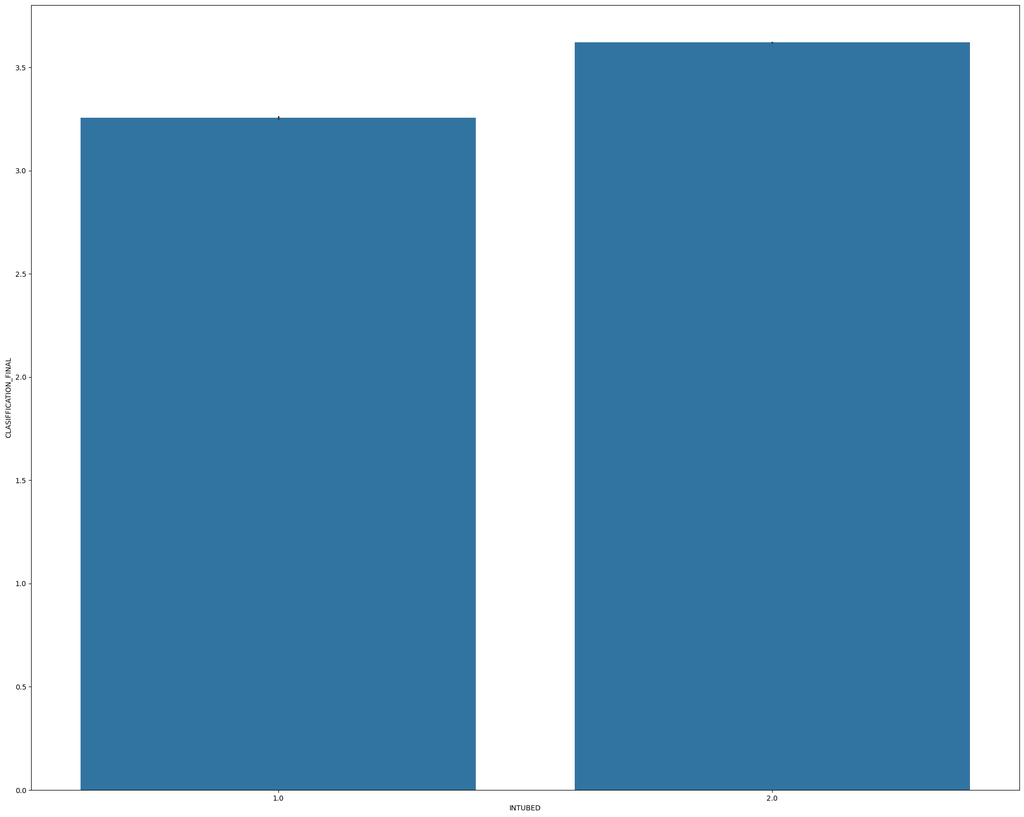

```python
plt.figure(figsize=(25,20))
sns.barplot(x='INTUBED',y='CLASIFFICATION_FINAL',data=df)
```

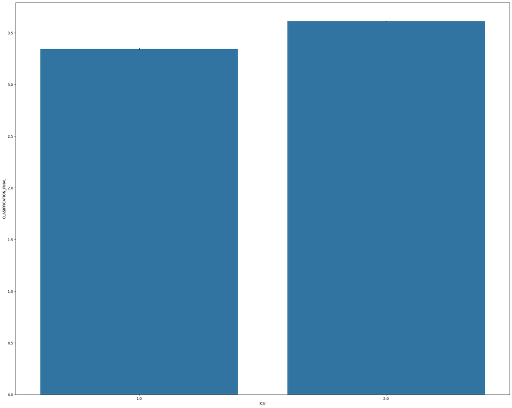

```python
plt.figure(figsize=(25,20))
sns.barplot(x='ICU',y='CLASIFFICATION_FINAL',data=df)
```

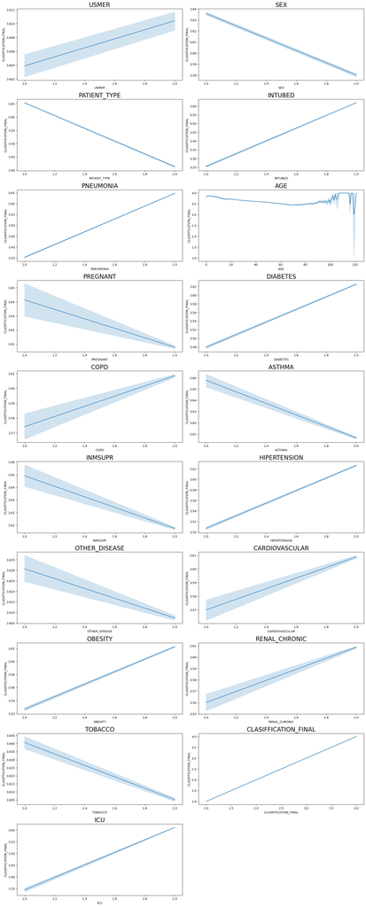

```python
plt.figure(figsize=(17,75))
for i in range(len(num_cols)):
  plt.subplot(18,2,i+1)
  sns.lineplot(x=num_cols[i],y=df['CLASIFFICATION_FINAL'],data=df)
  plt.tight_layout()
  plt.title(num_cols[i],fontsize=20)

plt.show()
```

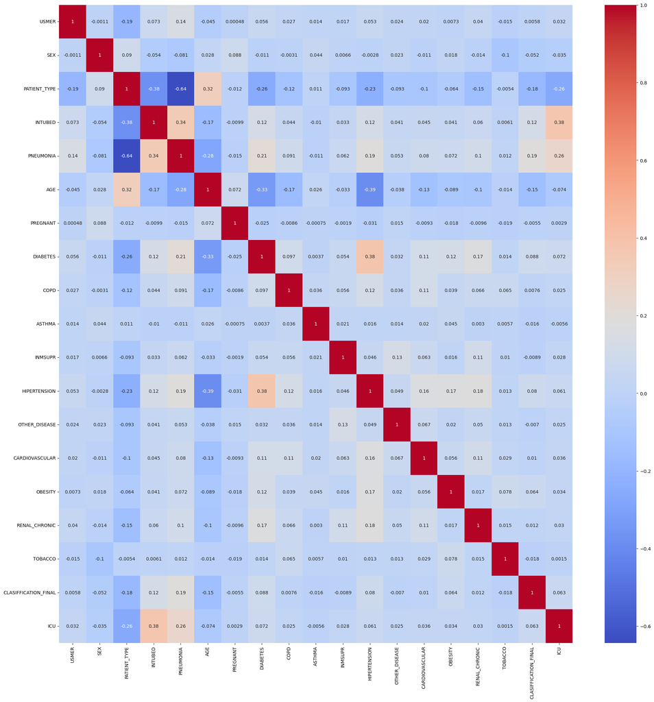

```python
plt.figure(figsize=(25,25))
num_cols= df.select_dtypes(include=["number"])
sns.heatmap(num_cols.corr(),annot=True,cmap="coolwarm")
```

START BUILDING THE MODEL AFTER VARIABLE ANALYSIS

```python
df.info()
```

```
<class 'pandas.core.frame.DataFrame'>
RangeIndex: 1048575 entries, 0 to 1048574
Data columns (total 20 columns):
 #   Column                Non-Null Count    Dtype
---  ------                --------------    -----
 0   USMER                 1048575 non-null  int64
 1   SEX                   1048575 non-null  int64
 2   PATIENT_TYPE          1048575 non-null  int64
 3   DATE_DIED             76942 non-null    object
 4   INTUBED               1048575 non-null  float64
 5   PNEUMONIA             1048575 non-null  float64
 6   AGE                   1048575 non-null  int64
 7   PREGNANT              1048575 non-null  float64
 8   DIABETES              1048575 non-null  float64
 9   COPD                  1048575 non-null  float64
 10  ASTHMA                1048575 non-null  float64
 11  INMSUPR               1048575 non-null  float64
 12  HIPERTENSION          1048575 non-null  float64
 13  OTHER_DISEASE         1048575 non-null  float64
 14  CARDIOVASCULAR        1048575 non-null  float64
 15  OBESITY               1048575 non-null  float64
 16  RENAL_CHRONIC         1048575 non-null  float64
 17  TOBACCO               1048575 non-null  float64
 18  CLASIFFICATION_FINAL  1048575 non-null  int64
 19  ICU                   1048575 non-null  float64
dtypes: float64(14), int64(5), object(1)
memory usage: 160.0+ MB
```

```python
df.head()
```

|  | USMER | SEX | PATIENT_TYPE | DATE_DIED | INTUBED | PNEUMONIA | AGE | PREGNANT | DIABETES | COPD | ASTHMA | INMSUPR | HIPERTENSION | OTHER_DISEASE | CARDIOVASCULAR | OBESITY | RENAL_CHRONIC | TOBACCO | CLASIFFICATION_FINAL | ICU |
| --- | --- | --- | --- | --- | --- | --- | --- | --- | --- | --- | --- | --- | --- | --- | --- | --- | --- | --- | --- | --- |
| 0 | 2 | 1 | 1 | 3/5/20 | 2.0 | 1.0 | 65 | 2.0 | 2.0 | 2.0 | 2.0 | 2.0 | 1.0 | 2.0 | 2.0 | 2.0 | 2.0 | 2.0 | 3 | 2.0 |
| 1 | 2 | 2 | 1 | 3/6/20 | 2.0 | 1.0 | 72 | 2.0 | 2.0 | 2.0 | 2.0 | 2.0 | 1.0 | 2.0 | 2.0 | 1.0 | 1.0 | 2.0 | 4 | 2.0 |
| 2 | 2 | 2 | 2 | 9/6/20 | 1.0 | 2.0 | 55 | 2.0 | 1.0 | 2.0 | 2.0 | 2.0 | 2.0 | 2.0 | 2.0 | 2.0 | 2.0 | 2.0 | 3 | 2.0 |
| 3 | 2 | 1 | 1 | 12/6/20 | 2.0 | 2.0 | 53 | 2.0 | 2.0 | 2.0 | 2.0 | 2.0 | 2.0 | 2.0 | 2.0 | 2.0 | 2.0 | 2.0 | 4 | 2.0 |
| 4 | 2 | 2 | 1 | 21/06/2020 | 2.0 | 2.0 | 68 | 2.0 | 1.0 | 2.0 | 2.0 | 2.0 | 1.0 | 2.0 | 2.0 | 2.0 | 2.0 | 2.0 | 3 | 2.0 |

```python
#define X and Y variables for RandomForest model
X= df.drop(['CLASIFFICATION_FINAL','DATE_DIED'],axis=1)
y=df[['CLASIFFICATION_FINAL']]
```

```python
print(X.shape)
print(y.shape)
```

```
(1048575, 18)
(1048575, 1)
```

```python
X.head()
```

|  | USMER | SEX | PATIENT_TYPE | INTUBED | PNEUMONIA | AGE | PREGNANT | DIABETES | COPD | ASTHMA | INMSUPR | HIPERTENSION | OTHER_DISEASE | CARDIOVASCULAR | OBESITY | RENAL_CHRONIC | TOBACCO | ICU |
| --- | --- | --- | --- | --- | --- | --- | --- | --- | --- | --- | --- | --- | --- | --- | --- | --- | --- | --- |
| 0 | 2 | 1 | 1 | 2.0 | 1.0 | 65 | 2.0 | 2.0 | 2.0 | 2.0 | 2.0 | 1.0 | 2.0 | 2.0 | 2.0 | 2.0 | 2.0 | 2.0 |
| 1 | 2 | 2 | 1 | 2.0 | 1.0 | 72 | 2.0 | 2.0 | 2.0 | 2.0 | 2.0 | 1.0 | 2.0 | 2.0 | 1.0 | 1.0 | 2.0 | 2.0 |
| 2 | 2 | 2 | 2 | 1.0 | 2.0 | 55 | 2.0 | 1.0 | 2.0 | 2.0 | 2.0 | 2.0 | 2.0 | 2.0 | 2.0 | 2.0 | 2.0 | 2.0 |
| 3 | 2 | 1 | 1 | 2.0 | 2.0 | 53 | 2.0 | 2.0 | 2.0 | 2.0 | 2.0 | 2.0 | 2.0 | 2.0 | 2.0 | 2.0 | 2.0 | 2.0 |
| 4 | 2 | 2 | 1 | 2.0 | 2.0 | 68 | 2.0 | 1.0 | 2.0 | 2.0 | 2.0 | 1.0 | 2.0 | 2.0 | 2.0 | 2.0 | 2.0 | 2.0 |

```python
#X['DATE_DIED']= X['DATE_DIED'].astype('object')
X['USMER']= X['USMER'].astype('object')
```

```python
from sklearn.model_selection import train_test_split
X_train,X_test,y_train,y_test = train_test_split(X,y,test_size=0.2,random_state=42)
```

```python
X_train.head(2)
```

|  | USMER | SEX | PATIENT_TYPE | INTUBED | PNEUMONIA | AGE | PREGNANT | DIABETES | COPD | ASTHMA | INMSUPR | HIPERTENSION | OTHER_DISEASE | CARDIOVASCULAR | OBESITY | RENAL_CHRONIC | TOBACCO | ICU |
| --- | --- | --- | --- | --- | --- | --- | --- | --- | --- | --- | --- | --- | --- | --- | --- | --- | --- | --- |
| 408561 | 2 | 2 | 1 | 2.0 | 2.0 | 62 | 2.0 | 1.0 | 2.0 | 2.0 | 2.0 | 2.0 | 2.0 | 1.0 | 2.0 | 2.0 | 1.0 | 2.0 |
| 70143 | 2 | 2 | 1 | 2.0 | 2.0 | 57 | 2.0 | 2.0 | 2.0 | 2.0 | 2.0 | 2.0 | 2.0 | 2.0 | 2.0 | 2.0 | 2.0 | 2.0 |

```python
print(X_train.shape)
print(y_train.shape)
print(X_test.shape)
print(y_test.shape)
```

```
(838860, 18)
(838860, 1)
(209715, 18)
(209715, 1)
```

```python
from sklearn.ensemble import RandomForestClassifier,RandomForestRegressor
from sklearn.impute import SimpleImputer

linearregression = LinearRegression()
linearregression.fit(X_train,y_train)
```

```
LinearRegression()
```

```python
print("Intercept: ",linearregression.intercept_)
print("\nCoeffs: ", linearregression.coef_)
```

```
Intercept:  [4.1241163]

Coeffs:  [[-0.03302387 -0.0389107  -0.09750438  0.14161715  0.16453854 -0.00276158
   0.03032741  0.02792318 -0.10349311 -0.03279411 -0.09578136  0.0056588
  -0.06101671 -0.06087658  0.06993995 -0.07179909 -0.05122686 -0.0347691 ]]
```

```python
y_pred= linearregression.predict(X_test)
```

```python
mse= mean_absolute_error(y_test,y_pred)
print(mse)
```

```
0.4598995526421991
```

```python
msqe= mean_squared_error(y_test,y_pred) **.5
print(msqe)
```

```
0.5232064787274107
```

```python
r2_score(y_test,y_pred)
```

```
0.05529206890130678
```

```python
X_train1,X_test1,y_train1,y_test1 = train_test_split(X,y,test_size= 0.3,random_state=42)
X_train1= sm.add_constant(X_train1)
X_test1 = sm.add_constant(X_test1)
print(X_train1.shape)
print(y_train1.shape)
print(X_test1.shape)
print(y_test1.shape)
```

```
(734002, 19)
(734002, 1)
(314573, 19)
(314573, 1)
```

```python
y_train1= y_train1.astype(float)
X_train1= X_train1.astype(float)
olsmod1= sm.OLS(y_train1,X_train1)
olsres1= olsmod1.fit()
print(olsres1.summary())
```

```
                             OLS Regression Results
================================================================================
Dep. Variable:     CLASIFFICATION_FINAL   R-squared:                       0.057
Model:                              OLS   Adj. R-squared:                  0.057
Method:                   Least Squares   F-statistic:                     2445.
Date:                  Sat, 27 Apr 2024   Prob (F-statistic):               0.00
Time:                          03:10:14   Log-Likelihood:            -5.6805e+05
No. Observations:                734002   AIC:                         1.136e+06
Df Residuals:                    733983   BIC:                         1.136e+06
Df Model:                            18
Covariance Type:              nonrobust
==================================================================================
                     coef    std err          t      P>|t|      [0.025      0.975]
----------------------------------------------------------------------------------
const              4.1257      0.028    146.219      0.000       4.070       4.181
USMER             -0.0335      0.001    -25.837      0.000      -0.036      -0.031
SEX               -0.0388      0.001    -31.181      0.000      -0.041      -0.036
PATIENT_TYPE      -0.0976      0.002    -44.879      0.000      -0.102      -0.093
INTUBED            0.1416      0.004     35.659      0.000       0.134       0.149
PNEUMONIA          0.1654      0.002     68.956      0.000       0.161       0.170
AGE               -0.0028   4.19e-05    -65.967      0.000      -0.003      -0.003
PREGNANT           0.0287      0.007      4.082      0.000       0.015       0.043
DIABETES           0.0275      0.002     12.946      0.000       0.023       0.032
COPD              -0.1038      0.005    -19.673      0.000      -0.114      -0.093
ASTHMA            -0.0320      0.004     -8.905      0.000      -0.039      -0.025
INMSUPR           -0.0959      0.005    -17.810      0.000      -0.106      -0.085
HIPERTENSION       0.0064      0.002      3.267      0.001       0.003       0.010
OTHER_DISEASE     -0.0625      0.004    -16.212      0.000      -0.070      -0.055
CARDIOVASCULAR    -0.0609      0.005    -13.455      0.000      -0.070      -0.052
OBESITY            0.0708      0.002     40.648      0.000       0.067       0.074
RENAL_CHRONIC     -0.0704      0.005    -14.838      0.000      -0.080      -0.061
TOBACCO           -0.0513      0.002    -22.486      0.000      -0.056      -0.047
ICU               -0.0357      0.005     -6.689      0.000      -0.046      -0.025
==============================================================================
Omnibus:                   175780.182   Durbin-Watson:                   2.000
Prob(Omnibus):                  0.000   Jarque-Bera (JB):           465900.475
Skew:                          -1.292   Prob(JB):                         0.00
Kurtosis:                       5.924   Cond. No.                     2.14e+03
==============================================================================

Notes:
[1] Standard Errors assume that the covariance matrix of the errors is correctly specified.
[2] The condition number is large, 2.14e+03. This might indicate that there are
strong multicollinearity or other numerical problems.
```

```python
from statsmodels.stats.outliers_influence import variance_inflation_factor
vif_series1=pd.Series([variance_inflation_factor(X_train1.values,i) for i in range(X_train1.shape[1])],index=X_train1.columns)
print('Before feature Selection: \n\n{}\n'.format(vif_series1))
```

```
Before feature Selection:

const             2122.954167
USMER                1.040759
SEX                  1.032653
PATIENT_TYPE         1.948336
INTUBED              1.307553
PNEUMONIA            1.776550
AGE                  1.339606
PREGNANT             1.015814
DIABETES             1.266206
COPD                 1.051265
ASTHMA               1.007663
INMSUPR              1.036532
HIPERTENSION         1.345878
OTHER_DISEASE        1.028727
CARDIOVASCULAR       1.053193
OBESITY              1.043532
RENAL_CHRONIC        1.072481
TOBACCO              1.022095
ICU                  1.201380
dtype: float64
```

```python
#drop highest vif values and adjust r^2
X_train2 = X_train1.drop('PATIENT_TYPE',axis=1)
vif_series2 = pd.Series([variance_inflation_factor(X_train2.values,i) for i in range(X_train2.shape[1])],index=X_train2.columns)
print('Before Feature Selection , after removing PATIENT TYPE: \n\n{}\n'.format(vif_series2))
```

```
Before Feature Selection , after removing PATIENT TYPE:

const             1847.565944
USMER                1.024372
SEX                  1.029648
INTUBED              1.270007
PNEUMONIA            1.277569
AGE                  1.321691
PREGNANT             1.013534
DIABETES             1.258484
COPD                 1.049550
ASTHMA               1.007650
INMSUPR              1.034166
HIPERTENSION         1.343571
OTHER_DISEASE        1.025419
CARDIOVASCULAR       1.052752
OBESITY              1.043486
RENAL_CHRONIC        1.068346
TOBACCO              1.021902
ICU                  1.195178
dtype: float64
```

```python
olsmod2= sm.OLS(y_train1,X_train2)
olsres2=olsmod2.fit()
print(olsres2.summary())
```

```
                             OLS Regression Results
================================================================================
Dep. Variable:     CLASIFFICATION_FINAL   R-squared:                       0.054
Model:                              OLS   Adj. R-squared:                  0.054
Method:                   Least Squares   F-statistic:                     2463.
Date:                  Sat, 27 Apr 2024   Prob (F-statistic):               0.00
Time:                          03:11:04   Log-Likelihood:            -5.6906e+05
No. Observations:                734002   AIC:                         1.138e+06
Df Residuals:                    733984   BIC:                         1.138e+06
Df Model:                            17
Covariance Type:              nonrobust
==================================================================================
                     coef    std err          t      P>|t|      [0.025      0.975]
----------------------------------------------------------------------------------
const              3.6696      0.026    139.220      0.000       3.618       3.721
USMER             -0.0262      0.001    -20.339      0.000      -0.029      -0.024
SEX               -0.0418      0.001    -33.605      0.000      -0.044      -0.039
INTUBED            0.1717      0.004     43.839      0.000       0.164       0.179
PNEUMONIA          0.2225      0.002    109.213      0.000       0.218       0.226
AGE               -0.0030   4.17e-05    -71.539      0.000      -0.003      -0.003
PREGNANT           0.0437      0.007      6.206      0.000       0.030       0.057
DIABETES           0.0350      0.002     16.479      0.000       0.031       0.039
COPD              -0.0942      0.005    -17.850      0.000      -0.105      -0.084
ASTHMA            -0.0326      0.004     -9.052      0.000      -0.040      -0.026
INMSUPR           -0.0844      0.005    -15.662      0.000      -0.095      -0.074
HIPERTENSION       0.0101      0.002      5.122      0.000       0.006       0.014
OTHER_DISEASE     -0.0527      0.004    -13.670      0.000      -0.060      -0.045
CARDIOVASCULAR    -0.0567      0.005    -12.523      0.000      -0.066      -0.048
OBESITY            0.0703      0.002     40.298      0.000       0.067       0.074
RENAL_CHRONIC     -0.0572      0.005    -12.058      0.000      -0.066      -0.048
TOBACCO           -0.0527      0.002    -23.072      0.000      -0.057      -0.048
ICU               -0.0185      0.005     -3.469      0.001      -0.029      -0.008
==============================================================================
Omnibus:                   175470.248   Durbin-Watson:                   2.001
Prob(Omnibus):                  0.000   Jarque-Bera (JB):           463053.208
Skew:                          -1.292   Prob(JB):                         0.00
Kurtosis:                       5.909   Cond. No.                     2.00e+03
==============================================================================

Notes:
[1] Standard Errors assume that the covariance matrix of the errors is correctly specified.
[2] The condition number is large,  2e+03. This might indicate that there are
strong multicollinearity or other numerical problems.
```

We conclude that there is no multicolinearity because there is no such column in olsres1 that has a VIF score that is greater than 5, infact all of them are less than 2.

```python
residual = olsres1.resid
np.mean(residual)
```

```
1.2556194928433872e-15
```

We also see that the mean oof residuals is very close to 0

```python
residual=olsres1.resid
fitted=olsres1.fittedvalues
```

```python
#sns.set_style("whitegrid")
#sns.residplot(fitted,residual,lowess=True)
#plt.xlabel("fitted vals")
#plt.ylabel("resid")
#plt.title("resid plt")
#plt.show()
```

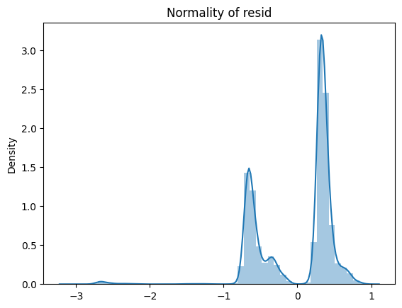

```python
sns.distplot(residual)
plt.title('Normality of resid')
plt.show()
```

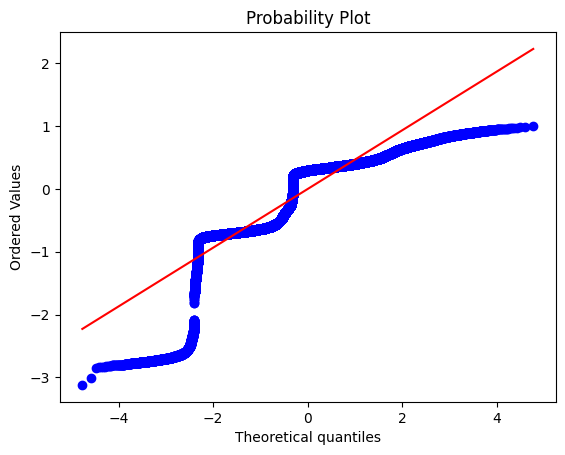

```python
import pylab
import scipy.stats as stats
stats.probplot(residual, dist="norm",plot=pylab)
plt.show()
```

```python
import statsmodels.stats.api as sms
from statsmodels.compat import lzip

name = ['F statistic','p-value']
test = sms.het_goldfeldquandt(residual,X_train1)
lzip(name,test)
```

```
[('F statistic', 1.000988552919186), ('p-value', 0.38236327623847804)]
```

```python
y_pred_final = olsres1.predict(X_test1)
```

```python
from sklearn.metrics import mean_squared_error
rms = np.sqrt(mean_squared_error(y_train1,fitted))
print('rmse for training dataset: ',rms)

rms1 = np.sqrt(mean_squared_error(y_test1,y_pred_final))
print('rmse for test dataset: ', rms1)
```

```
rmse for training dataset:  0.5246479361030233
rmse for test dataset:  0.52304902545513
```

```python
import tensorflow as tf
from tensorflow import keras
from keras import backend
from keras.models import Sequential
from keras.layers import Dense, Dropout

from tensorflow.keras.losses import binary_crossentropy

# importing SMOTE
from imblearn.over_sampling import SMOTE

# importing metrics
from sklearn.metrics import confusion_matrix,roc_curve,classification_report,recall_score

import random
import numpy as np
```

Neural Network Implementation:

```python
backend.clear_session()
np.random.seed(2)
random.seed(2)
tf.random.set_seed(2)
```

```python
model_1 = Sequential()
model_1.add(Dense(64,activation='relu',input_dim = X_train.shape[1]))
model_1.add(Dense(16,activation='relu'))
model_1.add(Dense(1, activation = 'sigmoid'))
optimizer = tf.keras.optimizers.Adam(0.001)
metric = keras.metrics.Recall()
model_1.compile(loss='binary_crossentropy',optimizer=optimizer,metrics=[metric])
```

```python
model_1.summary()
```

```
Model: "sequential_2"
_________________________________________________________________
 Layer (type)                Output Shape              Param #
=================================================================
 dense_6 (Dense)             (None, 64)                1216

 dense_7 (Dense)             (None, 16)                1040

 dense_8 (Dense)             (None, 1)                 17

=================================================================
Total params: 2273 (8.88 KB)
Trainable params: 2273 (8.88 KB)
Non-trainable params: 0 (0.00 Byte)
_________________________________________________________________
```

```python
import random
from keras.callbacks import History
X_test= np.asarray(X_test).astype('float32')
y_test = np.asarray(y_test).astype('float32')
X_train= np.asarray(X_test).astype('float32')
y_train = np.asarray(y_test).astype('float32')
history_1 = model_1.fit(
    X_train, y_train,
    batch_size=32,
    epochs=10,
    validation_data=(X_test, y_test),
    verbose=1
)
```

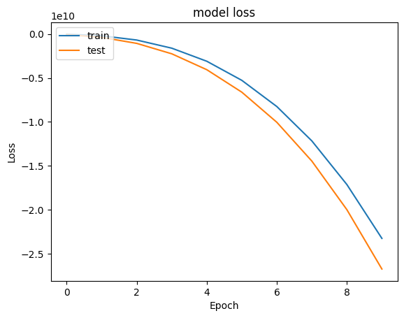

```python
plt.plot(history_1.history['loss'])
plt.plot(history_1.history['val_loss'])
plt.title('model loss')
plt.ylabel('Loss')
plt.xlabel('Epoch')
plt.legend(['train', 'test'], loc='upper left')
plt.show()
```

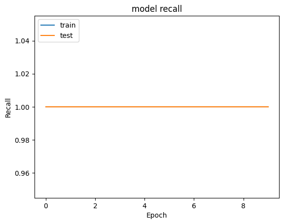

```python
plt.plot(history_1.history['recall_2'])
plt.plot(history_1.history['val_recall_2'])
plt.title('model recall')
plt.ylabel('Recall')
plt.xlabel('Epoch')
plt.legend(['train', 'test'], loc='upper left')
plt.show()
```

```python
#Predicting the results using best as a threshold
y_train_pred = model_1.predict(X_train)
y_train_pred = (y_train_pred > 0.5)
y_train_pred
```

```
array([[ True],
       [ True],
       [ True],
       ...,
       [ True],
       [ True],
       [ True]])
```

```python
#Predicting the results using best as a threshold
y_test_pred = model_1.predict(X_test)
y_test_pred = (y_test_pred > 0.5)
y_test_pred
```

```
array([[ True],
       [ True],
       [ True],
       ...,
       [ True],
       [ True],
       [ True]])
```

```python
from sklearn.metrics import recall_score
train_metric_df = pd.DataFrame(columns=["Recall"])
test_metric_df = pd.DataFrame(columns=["Recall"])
model_name = "Neural network with Adam"
train_metric_df.loc[model_name] = recall_score(y_train, y_train_pred, average='micro')
test_metric_df.loc[model_name] = recall_score(y_test, y_test_pred, average='micro')
```

```python
#lassification report
cr = classification_report(y_train, y_train_pred)
print(cr)
```

```
              precision    recall  f1-score   support

         1.0       0.01      1.00      0.02      1681
         2.0       0.00      0.00      0.00       370
         3.0       0.00      0.00      0.00     76240
         4.0       0.00      0.00      0.00    131424

    accuracy                           0.01    209715
   macro avg       0.00      0.25      0.00    209715
weighted avg       0.00      0.01      0.00    209715
```

```python
#classification report
cr=classification_report(y_test,y_test_pred)
print(cr)
```

```
              precision    recall  f1-score   support

         1.0       0.01      1.00      0.02      1681
         2.0       0.00      0.00      0.00       370
         3.0       0.00      0.00      0.00     76240
         4.0       0.00      0.00      0.00    131424

    accuracy                           0.01    209715
   macro avg       0.00      0.25      0.00    209715
weighted avg       0.00      0.01      0.00    209715
```